# Practical Machine Learning Course Project

Wang Xuezhi

2019,3,28

## Synopsis

In this project, the goal is to use data from accelerometers on the belt, forearm, arm, and dumbell of 6 participants. They were asked to perform barbell lifts correctly and incorrectly in 5 different ways,build a model to predict the manner in which they did the exercise. This is the “classe” variable in the training set.

## Data Source

The training data for this project are available here: (Training data)[https://d396qusza40orc.cloudfront.net/predmachlearn/pml-training.csv]

The test data are available here: (Test data)[https://d396qusza40orc.cloudfront.net/predmachlearn/pml-testing.csv]

For more information about the Dataset: (More information about the Dataset)[http://groupware.les.inf.puc-rio.br/har]

## Library and Load the data

```r
library(caret)
```

```r
library(ggplot2)
Origintraining<-read.csv("pml-training.csv")
Origintesting<-read.csv("pml-testing.csv")
```

## Exploratory Data Analysis.

```r
dim(Origintraining)
```

```
## [1] 19622   160
```

```r
dim(Origintesting)
```

```
## [1]  20 160
```

Both datasets have 160 columes, training set has 19622 ovserves, testing set has 20 observes.

Use function apply to sum the NA in each columes. Plot the distribution of numbers of NA.

```r
NAcol<-apply(Origintraining,2,function(x){sum(is.na(x))})
summary(NAcol)
```

```
##    Min. 1st Qu.  Median    Mean 3rd Qu.    Max.
##       0       0       0    8047   19216   19216
```

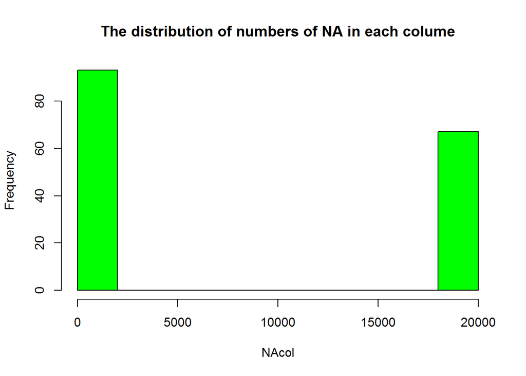

```r
hist(NAcol,col="green",main="The distribution of numbers of NA in each colume")
```

Through the plot, we can see there is a lot of columes containing 19216 NA out of 19622 observes. These variables are obviously not meaningful for model building. We only pick variables that contain 0 NA.

```r
Rtraining<-Origintraining[,which(NAcol==0)]
Rtesting<-Origintesting[,which(NAcol==0)]
```

By now, the dataset “Rtraining”and“Rtesting” have 93 variables respectively.

## Data preprocessing

#### Select numeric columes , then do standardizing on both training and testing set.

```r
numcol<-which(lapply(Rtraining,class)%in%"numeric")
prepro<-preProcess(Rtraining[,numcol],method=c('center','scale'))
trainingpre<-predict(prepro,Rtraining[,numcol])
trainingpre$classe<-Rtraining$classe
testingpre<-predict(prepro,Rtesting[,numcol])
```

By now, the datasets have 28 variables.

#### Removing the non zero Variables

```r
Nonzero<-nearZeroVar(trainingpre,saveMetrics=TRUE)
trainingpre1<-trainingpre[,Nonzero$nzv==FALSE]
```

The result dataset “trainingpre1” contains 28 variables too, it means there isn’t non zero Variables in dataset“trainingpre”.

#### PCA analysis

```r
prePCA<-preProcess(trainingpre1[,-28],method="pca")
trainPCA<-predict(prePCA,trainingpre1[,-28])
trainPCA<-data.frame(trainPCA,classe=trainingpre1$classe)
testPCA<-predict(prePCA,testingpre[,-28])
```

The result dataset “trainPCA” has 19 variables, dataset“testPCA” has 18 variables, the missing one is the movement type“classe” which we are going to predict through model.

## Create cross validation set

```r
set.seed(1)

inTrain<-createDataPartition(y=trainingpre1$classe,p=.6,list=FALSE)
straining<-trainPCA[inTrain,]
stesting<-trainPCA[-inTrain,]
```

## Train model

Use method“Tree”,“Random Forest”and “lda” to train a model, then test the accuracy on the training set itself.

Train with tree model, and get the accuracy.

```r
modtree<-train(classe~.,method="rpart",metric="Accuracy",data=straining)
treepre<-predict(modtree,straining)
treeaccu<-confusionMatrix(treepre,straining$classe)
treeaccu$overall[1]
```

```
##  Accuracy
## 0.3541101
```

Train with Randon Forest, and get the accuracy.

```r
modrf<-train(classe~.,method="rf",metric="Accuracy",data=straining)
rfpre<-predict(modrf,straining)
rfaccu<-confusionMatrix(rfpre,straining$classe)
rfaccu$overall[1]
```

```
## Accuracy
##        1
```

Train with LDA, and get the accuracy.

```r
modlda<-train(classe~.,method="lda",metric="Accuracy",data=straining)
ldapre<-predict(modlda,straining)
ldaaccu<-confusionMatrix(ldapre,straining$classe)
ldaaccu$overall[1]
```

```
##  Accuracy
## 0.4528702
```

From above, we can see only model built with Random Forest resulted in acceptable accuracy.

## Cross validation

Use the cross validation test set to verify the accuracy of the model.

```r
rftes<-predict(modrf,stesting)
CVaccu<-confusionMatrix(rftes,stesting$classe)
CVaccu$overall[1]
```

```
##  Accuracy
## 0.9622738
```

## Predict on test dataset

Apply the Random Forest model to the test dataset to get the predict.

```r
predict(modrf,testPCA)
```

```
##  [1] B A B A A E D B A A B C B A E E A B B B
## Levels: A B C D E
```